# Omnighost for First Pair Press

Publishing from Obsidian to Ghost Across Every Blog

Alexy Khrabrov

2026-07-23

# Omnighost for First Pair Press

Publishing from Obsidian to Ghost

Across Every Blog

Alexy Khrabrov

omnighost (0.16.1)

# 1 Preface

This is a field guide to **Omnighost**, the First Pair Press bridge from Obsidian to Ghost. It still assumes **no prior knowledge**: if you have never heard of Obsidian, never written a note in “Markdown,” and are not sure what a “vault” is, you are in exactly the right place.

The book is written with the **whole Obsidian loop** in mind: phone, tablet, laptop, desktop, and any synced vault that can run the plugin. First Pair Press uses that loop to draft anywhere and publish everywhere: a release note from an iPhone, a long essay from a Mac, an imported project announcement from a `.textpack`, or a photo-heavy post assembled inside a vault.

Omnighost is now part of the First Pair Press publishing stack. It turns notes into live Ghost posts, keeps those posts linked to their source notes, uploads local images, imports packaged drafts with their assets, and fans the same message out through multiple blogs without losing track of which post lives where.

A note on the pictures: the diagrams are drawn fresh for this book, and the phone screenshots are from the author’s own device. Where this book points you to features in detail, it links to the **official Obsidian documentation** at *help.obsidian.md* rather than copying it — that is always the most current source.

Let’s begin.

# 2 What Is Obsidian?

Imagine a drawer full of plain text files — one per idea, project, person, or day. Now imagine that drawer is searchable in an instant, that any note can *link* to any other note, and that the whole thing lives on your own device instead of someone else’s server. That, in one sentence, is Obsidian.

More precisely, Obsidian is an app for writing and connecting notes that are stored as **ordinary files on your device**. Three ideas make it tick.

**1. Your notes are plain files.** Each note is a normal text file with a `.md` extension (more on `.md` in a moment). You can open them in any other program, back them up like any other file, and read them in fifty years without needing Obsidian at all. Nothing is locked inside a proprietary database.

**2. Your notes live in a “vault.”** A *vault* is just a folder on your device that Obsidian watches. Everything in that folder — notes, images, sub-folders — is your vault. You can have one vault for everything, or several (work, personal, a journal). A vault is portable: copy the folder, and you’ve copied your whole knowledge base.

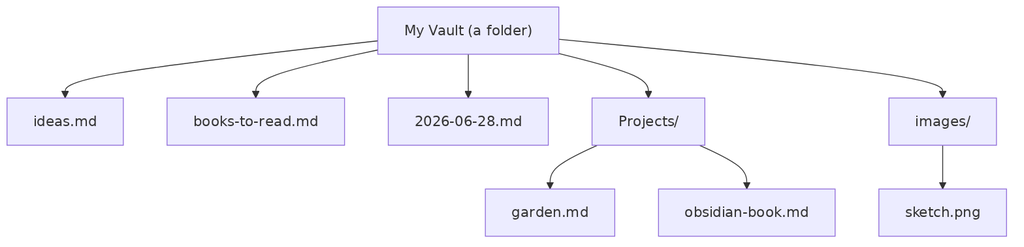

A vault is a folder containing Markdown notes, project folders, and images.

**3. Notes connect to each other.** The real magic is *linking*. Any note can point to any other note, and Obsidian remembers the connection in both directions. Over time your notes stop being a pile and start being a *web* — a personal Wikipedia where you are the only editor and the only reader.

For First Pair Press, that same plain-file vault is also the press room. A book idea, release announcement, technical note, and public essay can start as ordinary Markdown, collect images beside it, move between devices, and become a web post only when it is ready. Omnighost adds the publishing rail without taking the vault away from Obsidian.

## 2.1 Why people like it

- **Local and private.** By default your notes never leave your device unless you choose to sync or publish them.
- **It outlives the app.** Plain Markdown files are about as future-proof as a digital format gets.
- **It grows with you.** Start with a grocery list; end with a research system. The app doesn’t force a structure on you.
- **It’s extensible.** A large community builds *plugins* that add features — including the one in the last chapter of this book.

## 2.2 What Markdown is (the 90-second version)

Markdown is a way of writing formatted text using plain characters. Instead of clicking a “bold” button, you wrap a word in asterisks. Instead of a heading style, you start a line with `#`. It looks like this:

```
# A heading

This is a paragraph with a **bold** word and an *italic* one.

- a bullet
- another bullet

> a quoted line
```

You don’t have to memorize it — Obsidian shows you the formatted result as you type, and there is a one-page cheat sheet at the back of this book. The point is that the formatting is *part of the text*, so your notes stay readable anywhere.

# 3 Getting Started on Your Phone

Obsidian is free to download. The fastest path on a phone:

1. Open the **App Store** (iPhone/iPad) or **Google Play** (Android) and search for **Obsidian**. Install it.
2. Open the app. The first time, it offers to **create a vault** or open an existing one. Choose **Create new vault**, give it a name (e.g. *Notes*), and pick where it lives.
3. On iPhone you’ll typically choose between storing the vault **on your device** or **in iCloud Drive** (handy if you also use a Mac). On Android you pick a folder. Either is fine to start; you can move it later.
4. Tap the **+** (new note), type something, and you’ve made your first note.

That’s genuinely it — you now have a working second brain in your pocket.

## 3.1 A quick tour of the screen

If you ever feel lost, remember two gestures: **swipe from the left** for your files, and open the **command palette** to search for any action by name.

## 3.2 On editing modes

Obsidian can show a note two ways. **Live Preview** formats text as you write (bold looks bold). **Source mode** shows the raw Markdown characters. Beginners usually live in Live Preview; switch to Source when you want to see exactly what’s in the file. You can toggle between them from the command palette or the note’s “more options” menu.

# 4 Writing in Markdown

You already saw the basics. Here is the working set you’ll use 95% of the time.

**Headings** structure a note. One `#` is the biggest; more `#` make smaller sub-headings.

```
# Title
## Section
### Sub-section
```

**Emphasis**:

```
*italic*  or  _italic_
**bold**  or  __bold__
~~strikethrough~~
```

**Lists** — bullets with `-`, numbers with `1.`:

```
- milk
- eggs

1. wake up
2. coffee
```

**Checkboxes** turn a list into a to-do list. Tap a box in Live Preview to check it off:

```
- [ ] write a note
- [x] install Obsidian
```

**Quotes** and **code**:

```
> A quoted thought.

Inline `code` for a command. For several lines of code or commands, fence them with three backticks on their own lines, above and below.
```

**Images** can be dropped or pasted into a note; Obsidian stores the file in your vault and writes a link to it for you.

The golden rule: when in doubt, just *type*. Markdown is forgiving, and anything it doesn’t recognize is simply shown as plain text.

# 5 Linking Your Thoughts

This is the chapter that turns a notes app into *Obsidian*.

To link from one note to another, type two square brackets and start typing a name:

```
See also [[Books to read]] and [[Garden]].
```

As you type inside the brackets, Obsidian suggests matching notes. Pick one and you’ve made a link. Tap the link later to jump there. If the target note doesn’t exist yet, the link is created “empty” — tap it and Obsidian makes the note for you. This is a lovely way to write: mention an idea now, flesh it out later.

## 5.1 Backlinks: connections in reverse

Here’s the part that feels like magic. If note A links to note B, then note B automatically knows that A points at it. Open B, look at its **Backlinks** panel, and you’ll see every note that mentions it — without you ever editing B.

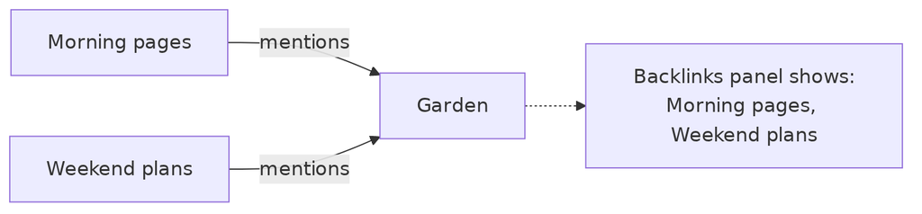

Backlinks show which notes point at the current note.

Backlinks mean you never lose a thought. Write about your garden in today’s journal, and the *Garden* note quietly collects every mention over the months.

## 5.2 The graph

Obsidian can draw your whole vault as a **graph**: each note is a dot, each link a line. Early on it’s a few scattered dots. After a few hundred notes it becomes a constellation, and clusters appear where your real interests live. The graph is more fun than useful at first — but it’s a great way to *see* your thinking take shape.

## 5.3 Tags

Sometimes you don’t want a whole note for a topic — you just want a label. Type a `#` followed by a word, with no space:

```
Had a great idea on the bus today. #ideas #commute
```

Tags are searchable and clickable. They’re a lighter-weight cousin of links: links connect specific notes; tags gather many notes under a theme.

# 6 Organizing a Vault

There is no single “right” way to organize Obsidian, which is liberating and, at first, slightly terrifying. Three tools help, and you can mix them freely.

**Folders** work exactly as you’d expect — drag notes into them, nest them. Good for coarse separation (Work, Personal, Journal). Don’t over-think folders; linking and search make deep hierarchies unnecessary.

**Tags** (from the last chapter) cut *across* folders. A note in `Work/` can carry `#idea` right alongside a note in `Personal/`.

**Properties** are the most powerful and the least obvious, so they get their own section.

## 6.1 Properties (the note’s “data”)

Every note can carry a small block of structured information at the very top, called **properties** (the underlying format is called *YAML frontmatter*). It’s fenced by three dashes:

```
---
title: Trip to Los Cabos
status: draft
tags: [travel, 2026]
rating: 5
---

The body of the note starts here.
```

Each line is a **key** and a **value**. Obsidian shows these as a tidy **Properties panel** at the top of the note, with the right input for each type — a checkbox for yes/no, a date picker for dates, a list editor for lists.

[figure not shown]

A few common cases and what they mean:

- **“Successfully connected” shows the wrong name, or connection fails** — check that blog’s Ghost URL, **Use staff access token** toggle, and credential. An Admin API key entered while Staff mode is on — or the reverse — will not authenticate correctly. Re-enter the matching credential in the blog block; the greeting confirms the right site.
- **A slug-length error** (as pictured) — the note had no heading, so the title fell back to a long first paragraph. Give the note a short `# Heading` or set `g_slug` explicitly.
- **The post looks “paywalled” but you set it public** — check the body: if the *content* is visible and only a *Subscribe* box sits at the bottom, that box is Ghost’s normal newsletter call-to-action on public posts, not a lock. Confirm the visibility in Ghost admin to be sure.
- **It shows “Published” but you got an error** — newer versions tie the green “Published” badge to a real published URL, so a failed sync won’t falsely show green. If yours does, update the plugin.
- **A blog sync says the key is missing** — each blog needs its own stored credential. Leave Staff mode off and paste an integration key into **Admin API key**, or turn Staff mode on and paste the user token into **Staff access token**, then tap **Save key**.
- **An imported note is “chopped” or later text sits inside a code block or quote** — update Omnighost, then re-import the post. Current releases close imported fenced-code and blockquote runs at the correct boundary.

## 10.14 Updating from GitHub

BRAT remains the easiest automatic update route, but Omnighost can now replace its own installed bundle. Open the command palette and run **Update from GitHub**. The command downloads the current `main.js`, `manifest.json`, and `styles.css` from `firstpair/omnighost` on GitHub, stages all three, clears stale temporary or backup files left by an earlier attempt, and then replaces the installed files as one update. Even an unchanged file is refreshed, so the three-file bundle cannot become a mixture of releases.

If downloading or installing any file fails, Omnighost restores the previous bundle. After a successful update, restart Obsidian or reload the app so it runs the new `main.js`.

This command tracks the repository’s **main branch**, not a separately reviewed app-store release. Use it when you trust that repository and want its newest build. The command itself first appeared under the temporary name **Update from Codex**; current releases call it **Update from GitHub**.

## 10.15 Why updating is the whole point

Plenty of tools can *post* from a note. The hard part — and the reason this plugin exists — is *re-posting the same note without making a mess*, especially when the same announcement appears on several blogs. Omnighost keeps a stable link between one note and each of its Ghost posts: edit the note, sync, and the live posts change in place. The First Pair Press vault stays the single source of truth, and the web stays in step with it.

# 11 Where to Go Next

You now have the whole loop: capture ideas as notes, connect them with links, organize lightly with folders, tags, and properties, find anything in a tap, extend the app with plugins, sync across your devices, and — when a note is ready for the world — publish it through Omnighost to the First Pair Press web.

A few directions from here:

- **Lean on the official docs.** The most current, detailed reference is at *help.obsidian.md*, with developer material at *docs.obsidian.md*. When a menu or setting looks different from this book, trust the docs — apps move fast.
- **Build the press blogs deliberately.** Add one Ghost blog at a time, test its key, give it a clear folder, and publish one safe draft before turning on periodic sync.
- **Package announcements as textpacks.** For repo-driven projects, make the `.textpack` the handoff format so Markdown, images, and Omnighost metadata travel together.
- **Use multi-blog publishing when the audience overlaps.** A release can reach the press site, a project blog, and a personal channel from one source note.
- **Back up.** Your notes are plain files; treat them as precious and copy them somewhere safe.

Most of all: keep the loop alive. Write in Obsidian, review the properties, sync through Omnighost, then keep improving the source note as the public story evolves.

# 12 Appendix A: Markdown Cheat Sheet

```
# Heading 1        ## Heading 2        ### Heading 3
**bold**           *italic*            ~~strikethrough~~
- bullet           1. numbered         - [ ] / - [x] task
> quote            `inline code`       [[Link to a note]]
#tag               ![alt](image.png)   [text](https://link)

(For multi-line code, fence it with three backticks on their own lines.)
```

# 13 Appendix B: Omnighost Property Reference

With the default prefix the keys begin `ghost_`; many users shorten it to `g_`. The table below uses `g_` for compactness. If your prefix is `ghost_`, read `g_published` as `ghost_published`, and so on.

| Property | Type | Meaning |
| --- | --- | --- |
| `g_blog` | list of names or domains | Which blog(s) the note publishes to (default if absent) |
| `g_published` | checkbox | Off = draft, on = published |
| `g_post_access` | `public` / `members` / `paid` | Who can read it |
| `g_published_at` | date | Future date schedules the post |
| `g_featured` | checkbox | Mark as a featured post |
| `g_slug` | text | URL ending (empty = from title) |
| `g_tags` | list | Post tags |
| `g_excerpt` | text | Short summary (max 300 chars) |
| `g_feature_image` | text | Cover image URL |
| `g_cover_from_first_image` | checkbox | Use the first body image as the cover |
| `g_no_sync` | checkbox | Skip this note when syncing |
| `g_id_<blog>` | written by plugin | The Ghost id for one target blog, using a domain-based suffix |
| `g_url_<blog>` | written by plugin | The Ghost editor link for that blog’s post |
| `g_public_url_<blog>` | written by plugin | The live, public web address for that blog’s post |
| `g_archived` | written by plugin | True when a bulk-deleted local note is archived |
| `g_archived_at` | written by plugin | When the note was moved into the archive folder |
| `g_archived_from` | written by plugin | The note’s original vault path before archive |

Legacy single-blog notes may contain `g_id`, `g_url`, or `g_public_url`. Omnighost reads them for compatibility and migrates toward per-blog keys on later syncs.